# SA_05_ASSET_MINIM_INDEPTED_CY

## Overview

**Description**

Current year amount

**Table**

`SA-P05-T00-SUPPORT-ORGS` (one)

**Location code**

`SCHED-A-PART-05-SECTION-B-LINE-02-COL-B`, `SCHED-A-PART-05-SECTION-B-LINE-02-COL-A`

**Family**

`SCHED-A-PART-05-SECTION-B-LINE-02-COL-B`

**Data type**

numeric (xsd: USAmountNNType)

**Scope**

PZ

**Status**

unreviewed

2

xpaths mapped (2 observed)

31,853

filings with a value

2014–2024

tax years observed

2

open flags (1 errors)

## Flags

| Severity | Flag | Xpath | Detail |
| --- | --- | --- | --- |
| ⚠ error | `COLLISION` | IRS990ScheduleA/MinimumAssetAmountGrp/AcquisitionIndebtednessGrp/CurrentYearAmt | 7960 filings contain 2+ of its xpaths; most common set: /Return/ReturnData/IRS990ScheduleA/MinimumAssetAmountGrp/AcquisitionIndebtednessGrp/CurrentYearAmt ; /Return/ReturnData/IRS990ScheduleA/MinimumA… |
| ▲ warn | `INCIDENCE_BREAK` |  | 990EZ fill rate changes up to 3.9x year-on-year (in 2024) |

## Xpaths

All mapped xpaths (under /Return/ReturnData or /Return/ReturnHeader), oldest first. Charts label each series by its xpath.

| Xpath | Form | Chart label | First year | Last year | Versions | Filings | Repeats in |
| --- | --- | --- | --- | --- | --- | --- | --- |
| IRS990ScheduleA/MinimumAssetAmountGrp/AcquisitionIndebtednessGrp/PriorYearAmt | Sched A | …mumAssetAmountGrp/AcquisitionIndebtednessGrp/PriorYearAmt | 2014 | 2024 | 34 | 23,893 | 0.0% |
| IRS990ScheduleA/MinimumAssetAmountGrp/AcquisitionIndebtednessGrp/CurrentYearAmt | Sched A | …mAssetAmountGrp/AcquisitionIndebtednessGrp/CurrentYearAmt | 2014 | 2024 | 32 | 7,960 | 0.0% |

## Coverage

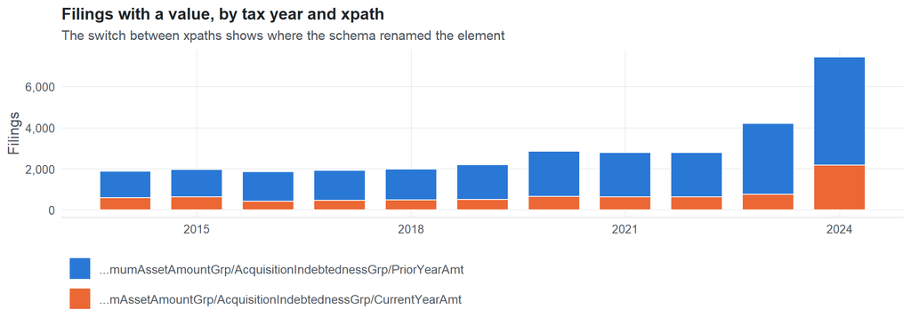

**Table view**

Table view: filings by tax year and series

| Tax year | …mumAssetAmountGrp/AcquisitionIndebtednessGrp/PriorYearAmt | …mAssetAmountGrp/AcquisitionIndebtednessGrp/CurrentYearAmt |
| --- | --- | --- |
| 2014 | 1293 | 589 |
| 2015 | 1330 | 635 |
| 2016 | 1426 | 429 |
| 2017 | 1456 | 461 |
| 2018 | 1503 | 482 |
| 2019 | 1682 | 507 |
| 2020 | 2198 | 659 |
| 2021 | 2149 | 639 |
| 2022 | 2145 | 634 |
| 2023 | 3454 | 752 |
| 2024 | 5257 | 2173 |

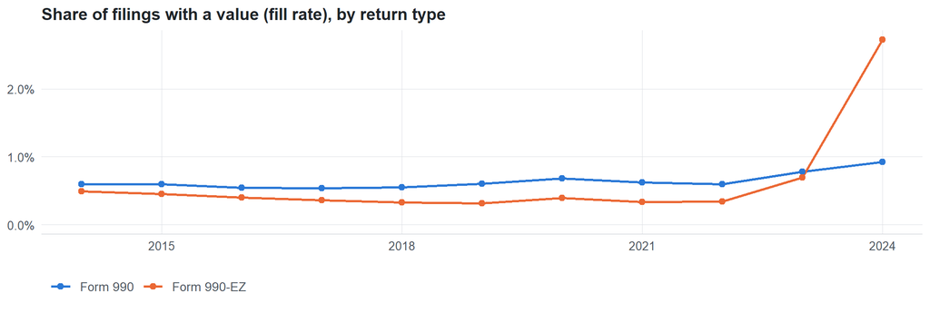

**Table view**

Table view: fill rate

| Tax year | Return type | Filings | All filings | Fill rate |
| --- | --- | --- | --- | --- |
| 2014 | Form 990 | 1,311 | 218,619 | 0.60% |
| 2014 | Form 990-EZ | 571 | 116,417 | 0.49% |
| 2015 | Form 990 | 1,397 | 233,519 | 0.60% |
| 2015 | Form 990-EZ | 568 | 124,894 | 0.45% |
| 2016 | Form 990 | 1,334 | 243,903 | 0.55% |
| 2016 | Form 990-EZ | 521 | 130,484 | 0.40% |
| 2017 | Form 990 | 1,414 | 261,612 | 0.54% |
| 2017 | Form 990-EZ | 503 | 139,144 | 0.36% |
| 2018 | Form 990 | 1,491 | 271,442 | 0.55% |
| 2018 | Form 990-EZ | 494 | 149,384 | 0.33% |
| 2019 | Form 990 | 1,708 | 283,694 | 0.60% |
| 2019 | Form 990-EZ | 481 | 152,622 | 0.32% |
| 2020 | Form 990 | 2,189 | 320,342 | 0.68% |
| 2020 | Form 990-EZ | 668 | 169,864 | 0.39% |
| 2021 | Form 990 | 2,104 | 336,480 | 0.63% |
| 2021 | Form 990-EZ | 684 | 202,724 | 0.34% |
| 2022 | Form 990 | 2,081 | 349,055 | 0.60% |
| 2022 | Form 990-EZ | 698 | 206,130 | 0.34% |
| 2023 | Form 990 | 2,767 | 354,768 | 0.78% |
| 2023 | Form 990-EZ | 1,439 | 206,379 | 0.70% |
| 2024 | Form 990 | 2,554 | 277,298 | 0.92% |
| 2024 | Form 990-EZ | 4,876 | 178,867 | 2.73% |

## Values

| Result | Check | Detail |
| --- | --- | --- |
| ✓ pass | Values parse as numbers | 100.0% of values are numeric |
| ⓘ info | Sign convention | 0.0% of values are negative (fine for net amounts) |

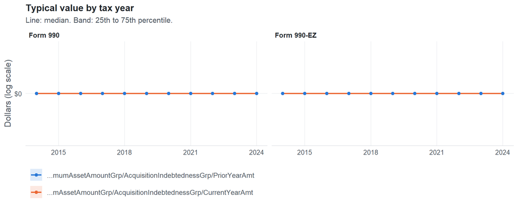

**Table view**

Table view: quartiles by tax year

| Series | Return | Tax year | Filings | P25 | Median | P75 |
| --- | --- | --- | --- | --- | --- | --- |
| …mumAssetAmountGrp/AcquisitionIndebtednessGrp/PriorYearAmt | 990 | 2014 | 870 | 0 | 0 | 0 |
| …mumAssetAmountGrp/AcquisitionIndebtednessGrp/PriorYearAmt | 990 | 2015 | 919 | 0 | 0 | 0 |
| …mumAssetAmountGrp/AcquisitionIndebtednessGrp/PriorYearAmt | 990 | 2016 | 988 | 0 | 0 | 0 |
| …mumAssetAmountGrp/AcquisitionIndebtednessGrp/PriorYearAmt | 990 | 2017 | 1,037 | 0 | 0 | 0 |
| …mumAssetAmountGrp/AcquisitionIndebtednessGrp/PriorYearAmt | 990 | 2018 | 1,094 | 0 | 0 | 0 |
| …mumAssetAmountGrp/AcquisitionIndebtednessGrp/PriorYearAmt | 990 | 2019 | 1,280 | 0 | 0 | 0 |
| …mumAssetAmountGrp/AcquisitionIndebtednessGrp/PriorYearAmt | 990 | 2020 | 1,663 | 0 | 0 | 0 |
| …mumAssetAmountGrp/AcquisitionIndebtednessGrp/PriorYearAmt | 990 | 2021 | 1,625 | 0 | 0 | 0 |
| …mumAssetAmountGrp/AcquisitionIndebtednessGrp/PriorYearAmt | 990 | 2022 | 1,621 | 0 | 0 | 0 |
| …mumAssetAmountGrp/AcquisitionIndebtednessGrp/PriorYearAmt | 990 | 2023 | 2,312 | 0 | 0 | 0 |
| …mumAssetAmountGrp/AcquisitionIndebtednessGrp/PriorYearAmt | 990 | 2024 | 2,199 | 0 | 0 | 0 |
| …mumAssetAmountGrp/AcquisitionIndebtednessGrp/PriorYearAmt | 990EZ | 2014 | 423 | 0 | 0 | 0 |
| …mumAssetAmountGrp/AcquisitionIndebtednessGrp/PriorYearAmt | 990EZ | 2015 | 411 | 0 | 0 | 0 |
| …mumAssetAmountGrp/AcquisitionIndebtednessGrp/PriorYearAmt | 990EZ | 2016 | 438 | 0 | 0 | 0 |
| …mumAssetAmountGrp/AcquisitionIndebtednessGrp/PriorYearAmt | 990EZ | 2017 | 419 | 0 | 0 | 0 |
| …mumAssetAmountGrp/AcquisitionIndebtednessGrp/PriorYearAmt | 990EZ | 2018 | 409 | 0 | 0 | 0 |
| …mumAssetAmountGrp/AcquisitionIndebtednessGrp/PriorYearAmt | 990EZ | 2019 | 402 | 0 | 0 | 0 |
| …mumAssetAmountGrp/AcquisitionIndebtednessGrp/PriorYearAmt | 990EZ | 2020 | 535 | 0 | 0 | 0 |
| …mumAssetAmountGrp/AcquisitionIndebtednessGrp/PriorYearAmt | 990EZ | 2021 | 524 | 0 | 0 | 0 |
| …mumAssetAmountGrp/AcquisitionIndebtednessGrp/PriorYearAmt | 990EZ | 2022 | 524 | 0 | 0 | 0 |
| …mumAssetAmountGrp/AcquisitionIndebtednessGrp/PriorYearAmt | 990EZ | 2023 | 1,142 | 0 | 0 | 0 |
| …mumAssetAmountGrp/AcquisitionIndebtednessGrp/PriorYearAmt | 990EZ | 2024 | 3,058 | 0 | 0 | 0 |
| …mAssetAmountGrp/AcquisitionIndebtednessGrp/CurrentYearAmt | 990 | 2014 | 441 | 0 | 0 | 0 |
| …mAssetAmountGrp/AcquisitionIndebtednessGrp/CurrentYearAmt | 990 | 2015 | 478 | 0 | 0 | 0 |
| …mAssetAmountGrp/AcquisitionIndebtednessGrp/CurrentYearAmt | 990 | 2016 | 346 | 0 | 0 | 0 |
| …mAssetAmountGrp/AcquisitionIndebtednessGrp/CurrentYearAmt | 990 | 2017 | 377 | 0 | 0 | 0 |
| …mAssetAmountGrp/AcquisitionIndebtednessGrp/CurrentYearAmt | 990 | 2018 | 397 | 0 | 0 | 0 |
| …mAssetAmountGrp/AcquisitionIndebtednessGrp/CurrentYearAmt | 990 | 2019 | 428 | 0 | 0 | 0 |
| …mAssetAmountGrp/AcquisitionIndebtednessGrp/CurrentYearAmt | 990 | 2020 | 526 | 0 | 0 | 0 |
| …mAssetAmountGrp/AcquisitionIndebtednessGrp/CurrentYearAmt | 990 | 2021 | 479 | 0 | 0 | 0 |
| …mAssetAmountGrp/AcquisitionIndebtednessGrp/CurrentYearAmt | 990 | 2022 | 460 | 0 | 0 | 0 |
| …mAssetAmountGrp/AcquisitionIndebtednessGrp/CurrentYearAmt | 990 | 2023 | 455 | 0 | 0 | 0 |
| …mAssetAmountGrp/AcquisitionIndebtednessGrp/CurrentYearAmt | 990 | 2024 | 355 | 0 | 0 | 0 |
| …mAssetAmountGrp/AcquisitionIndebtednessGrp/CurrentYearAmt | 990EZ | 2014 | 148 | 0 | 0 | 0 |
| …mAssetAmountGrp/AcquisitionIndebtednessGrp/CurrentYearAmt | 990EZ | 2015 | 157 | 0 | 0 | 0 |
| …mAssetAmountGrp/AcquisitionIndebtednessGrp/CurrentYearAmt | 990EZ | 2016 | 83 | 0 | 0 | 0 |
| …mAssetAmountGrp/AcquisitionIndebtednessGrp/CurrentYearAmt | 990EZ | 2017 | 84 | 0 | 0 | 0 |
| …mAssetAmountGrp/AcquisitionIndebtednessGrp/CurrentYearAmt | 990EZ | 2018 | 85 | 0 | 0 | 0 |
| …mAssetAmountGrp/AcquisitionIndebtednessGrp/CurrentYearAmt | 990EZ | 2019 | 79 | 0 | 0 | 0 |
| …mAssetAmountGrp/AcquisitionIndebtednessGrp/CurrentYearAmt | 990EZ | 2020 | 133 | 0 | 0 | 0 |
| …mAssetAmountGrp/AcquisitionIndebtednessGrp/CurrentYearAmt | 990EZ | 2021 | 160 | 0 | 0 | 0 |
| …mAssetAmountGrp/AcquisitionIndebtednessGrp/CurrentYearAmt | 990EZ | 2022 | 174 | 0 | 0 | 0 |
| …mAssetAmountGrp/AcquisitionIndebtednessGrp/CurrentYearAmt | 990EZ | 2023 | 297 | 0 | 0 | 0 |
| …mAssetAmountGrp/AcquisitionIndebtednessGrp/CurrentYearAmt | 990EZ | 2024 | 1,818 | 0 | 0 | 0 |

Summary by xpath and return type (all years)

| Series | Return | Filings | % numeric | % zero | % negative | Median (typical year) | P99 (typical year) |
| --- | --- | --- | --- | --- | --- | --- | --- |
| …mumAssetAmountGrp/AcquisitionIndebtednessGrp/PriorYearAmt | 990 | 15,608 | 100 | 99.2 | 0 | 0 | 0 |
| …mumAssetAmountGrp/AcquisitionIndebtednessGrp/PriorYearAmt | 990EZ | 8,285 | 100 | 100.0 | 0 | 0 | 0 |
| …mAssetAmountGrp/AcquisitionIndebtednessGrp/CurrentYearAmt | 990 | 4,742 | 100 | 97.8 | 0 | 0 | 605106 |
| …mAssetAmountGrp/AcquisitionIndebtednessGrp/CurrentYearAmt | 990EZ | 3,218 | 100 | 100 | 0 | 0 | 0 |

## Examples

| Tax year | Return | Xpath | Organization | Value | Source |
| --- | --- | --- | --- | --- | --- |
| 2024 | 990EZ | IRS990ScheduleA/MinimumAssetAmountGrp/AcquisitionIndebtednessGrp/CurrentYearAmt | GFT CHARITY INC | 0 | [XML](https://gt990datalake-rawdata.s3.amazonaws.com/EfileData/XmlFiles/202501339349206360_public.xml) |
| 2024 | 990EZ | IRS990ScheduleA/MinimumAssetAmountGrp/AcquisitionIndebtednessGrp/PriorYearAmt | Native Development Network | 0 | [XML](https://gt990datalake-rawdata.s3.amazonaws.com/EfileData/XmlFiles/202501789349200600_public.xml) |
| 2023 | 990 | IRS990ScheduleA/MinimumAssetAmountGrp/AcquisitionIndebtednessGrp/CurrentYearAmt | HISTORICAL FOUNDATION FOR | 0 | [XML](https://gt990datalake-rawdata.s3.amazonaws.com/EfileData/XmlFiles/202433179349305243_public.xml) |
| 2023 | 990 | IRS990ScheduleA/MinimumAssetAmountGrp/AcquisitionIndebtednessGrp/PriorYearAmt | LC DANESE G BORLAND CHARITTRUST | 0 | [XML](https://gt990datalake-rawdata.s3.amazonaws.com/EfileData/XmlFiles/202401089349300915_public.xml) |
| 2022 | 990 | IRS990ScheduleA/MinimumAssetAmountGrp/AcquisitionIndebtednessGrp/CurrentYearAmt | FLANAGAN PARK DISTRICT TRUST #130 | 0 | [XML](https://gt990datalake-rawdata.s3.amazonaws.com/EfileData/XmlFiles/202331359349310503_public.xml) |
| 2022 | 990 | IRS990ScheduleA/MinimumAssetAmountGrp/AcquisitionIndebtednessGrp/PriorYearAmt | GALAMIAN CHARITABLE TRUST | 0 | [XML](https://gt990datalake-rawdata.s3.amazonaws.com/EfileData/XmlFiles/202311289349302356_public.xml) |
| 2021 | 990 | IRS990ScheduleA/MinimumAssetAmountGrp/AcquisitionIndebtednessGrp/CurrentYearAmt | ANNE RAY FOUNDATION | 0 | [XML](https://gt990datalake-rawdata.s3.amazonaws.com/EfileData/XmlFiles/202213189349307286_public.xml) |
| 2021 | 990 | IRS990ScheduleA/MinimumAssetAmountGrp/AcquisitionIndebtednessGrp/PriorYearAmt | PACKARD W D FUND A OCHR | 0 | [XML](https://gt990datalake-rawdata.s3.amazonaws.com/EfileData/XmlFiles/202242799349301174_public.xml) |
| 2020 | 990 | IRS990ScheduleA/MinimumAssetAmountGrp/AcquisitionIndebtednessGrp/CurrentYearAmt | X245 FOUNDATION | 0 | [XML](https://gt990datalake-rawdata.s3.amazonaws.com/EfileData/XmlFiles/202103139349304680_public.xml) |
| 2020 | 990 | IRS990ScheduleA/MinimumAssetAmountGrp/AcquisitionIndebtednessGrp/PriorYearAmt | EMMA JONES TUW FOR VARIOUS 148-3010003 | 0 | [XML](https://gt990datalake-rawdata.s3.amazonaws.com/EfileData/XmlFiles/202101799349300755_public.xml) |
| 2019 | 990 | IRS990ScheduleA/MinimumAssetAmountGrp/AcquisitionIndebtednessGrp/CurrentYearAmt | Anna T Jeanes Foundation | 0 | [XML](https://gt990datalake-rawdata.s3.amazonaws.com/EfileData/XmlFiles/202141319349303414_public.xml) |
| 2019 | 990EZ | IRS990ScheduleA/MinimumAssetAmountGrp/AcquisitionIndebtednessGrp/PriorYearAmt | BETTE DAVIS FOUNDATION INC | 0 | [XML](https://gt990datalake-rawdata.s3.amazonaws.com/EfileData/XmlFiles/202011979349203166_public.xml) |

## Reviewer checklist

- The definition matches the form line and instructions for every xpath’s schema years.
- Every xpath pooled here measures the same thing on the 990 and 990-EZ (close enough for analysis).
- The coverage chart has no unexplained gaps or jumps between tax years.
- Each open flag is fixed, or accepted with a note in validation_log.csv.
- Values are whole dollars, not thousands, and not a percentage.
- Current year / prior year and beginning / end of year match the variable name (CY, PY, BOY, EOY).
- Negative values are expected only for net amounts (gains, net income, fund balances).
- The 990 and 990-EZ medians differ only as much as the filer populations do.

Record the review as a row in `inst/extdata/src/validation_log.csv` (variable_name, reviewer, date, status, note). Evidence built 2026-09-23 17:09:04 MST from the ef2 DuckDB builds (tax years 2009–2024).